# Tvyal Newsletter

2024-12-09

*English summary below.*

## 💵🪙🎭 Դրամի դրաման և ռուբլու ռումբը

Վերջին շաբաթվա ընթացքում դրամի արժևորումը որոշակի անհանգստություն է առաջացրել շուկայում։ Այս վերլուծությունը կուսումնասիրի դրամի փոխարժեքի փոփոխության պատմությունը, կբացատրի, թե ինչով է պայմանավորված դրամի արժևորումը։

Նախ հասկանանք, ինչով էր պայմանավորված հայկական դրամի կտրուկ արժեզրկումը և հետագա վերականգնումը։ Հայաստանի տնտեսությունը զգալի կախում ունի ռուսական տնտեսությունից։ Ինչպես քննարկել ենք մեր վերլուծություններում, 2022 թվականի տնտեսական աճը պայմանավորված էր Ռուսաստանից արտահոսած կապիտալով և աշխատուժով, իսկ 2023 թվականի տնտեսական աճը՝ Ռուսաստանից ոսկու վերաարտահանմամբ։ Հայաստանի պատրաստի ապրանքների գերակշռող մասը արտահանվում է Ռուսաստան։ Այս ֆոնին տարածաշրջանի արժույթների արժեզրկումը և հետագա վերականգնումը հիմնականում պայմանավորված էր հենց ռուբլու արժեզրկմամբ, որը պայմանավորված էր մի քանի հանգամանքով․

1. Նոյեմբերի 21-ին [ԱՄՆ Գանձապետարանը պատժամիջոցներ է կիրառել Գազպրոմբանկի նկատմամբ և լրացուցիչ քայլեր է ձեռնարկել՝ սահմանափակելու Ռուսաստանի միջազգային ֆինանսական համակարգի օգտագործումը](https://home.treasury.gov/news/press-releases/jy2725): Սա Ռուսաստանի վրա կիրառված պատժամիջոցների հերթական մասն էր։ Այս պահին ՌԴ վրա կիրառվում է [շուրջ 23 հազար պատժամիջոց](https://www.tvyal.com/newsletter/2024/2024_10_28): Նշենք, որ ԱՄՆ նախագահ Բայդենի ադմինիստրացիան մինչև վերջին պահը չէր կիրառում այս քայլը: Այս քայլը կարող է մեծացնել համաշխարհային գնաճը, քանի որ այս քայլը դժվարացնում է էներգառեսուրսների շարժը՝ թանկացնելով դրանք։
2. Եվրոպական հանձնաժողովի նախագահ Ուրսուլա ֆոն դեր Լեյենը վերընտրումից հետո հայտարարեց, որ Եվրամիությունը այլևս չի գնի ռուսական գազ, որը նույնպես ազդեցություն ունեցավ ռուբլու գնի վրա:
3. Ռուսաստանում յուրաքանչյուր տարվա վերջին ռուբլին ունի արժեզրկման միտում, քանի որ ռուսական կազմակերպությունները, որոնք արտարժույթով վարկ են վերցրել, տարվա վերջին վճարում են իրենց պարտավորությունները, ինչը մեծացնում է արտարժույթի հանդեպ պահանջարկը՝ արժեզրկելով ռուբլին:
4. ԱՄՆ նախագահ Թրամփի վերընտրումից հետո դոլարը սկսեց ամրանալ բոլոր արժույթների հանդեպ, որը նախանշում է համաշխարհային բիզնես միջավայրի վստահության մեծացումը ԱՄՆ-ի հանդեպ։

Այս իրադարձությունների արդյունքում ռուսական ռուբլին արժեզրկվեց՝ 1 դոլարը = 100 ռուբլուց (նոյեմբերի 17) մինչև 115 ռուբլի (նոյեմբերի 27)։ Նշենք, որ այս ազդեցությունը կարճաժամկետ էր, շուկան արդեն կարգավորվել է, և այս պահին՝ դեկտեմբերի 9-ի դրությամբ, [1 դոլարը արդեն 99 ռուբլի է](https://www.google.com/finance/quote/USD-RUB?window=1M)։

Դիտարկենք դոլարի, եվրոյի և ռուբլու փոխարժեքները Հայաստանի փոխանակման կետերում հոկտեմբերի 1-ից սկսած։

Գծապատկեր 1

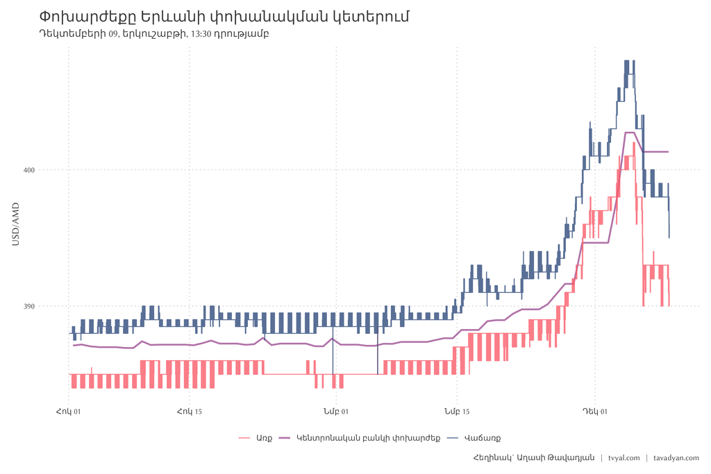

Գծապատկեր 2

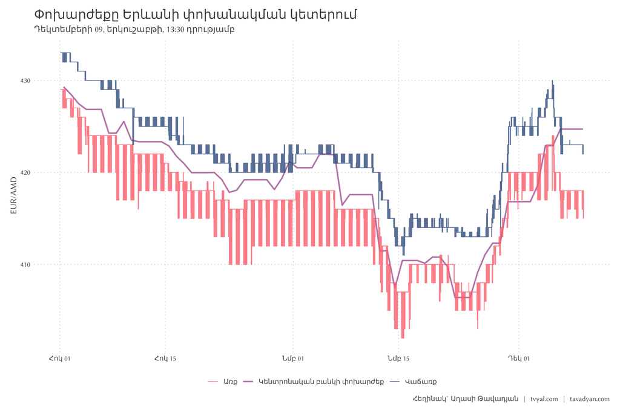

Գծապատկեր 3

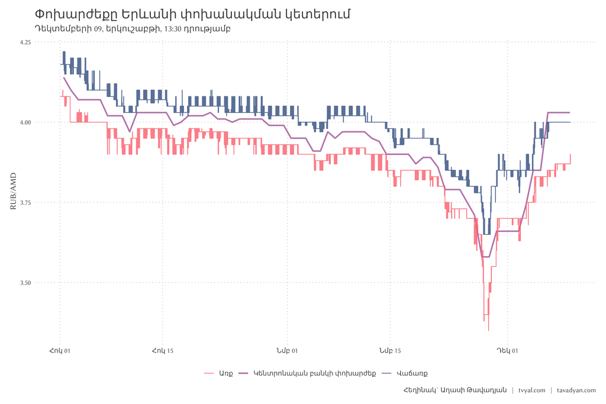

Ինչպես երևում է գծապատկերներից, փոխարժեքի տատանումը, որը որոշակի անհանգստություն առաջացրեց մեր շուկայում, արդեն հանդարտվել է։ Սա ցույց է տալիս նաև շուկայական մարժայի գծապատկերը (գծապատկեր 4), որն արտացոլում է յուրաքանչյուր փոխարժեքի հանդեպ անորոշության աստիճանը շուկայում։ Գծապատկերում պատկերված է փոխանակման կետերի մարժայի տարբերությունը ռուբլու, եվրոյի և դոլարի համար (Բանաձևը՝ (sell - buy) / buy)։ Մարժան ցույց է տալիս, թե որքան անորոշություն է շուկան տեսնում տվյալ փոխարժեքի մեջ։ Այս պահին իրավիճակը հանդարտվել է, և շուկան ակնկալում է, որ ամենայն հավանականությամբ իրավիճակը կայունանում է։

Գծապատկեր 4

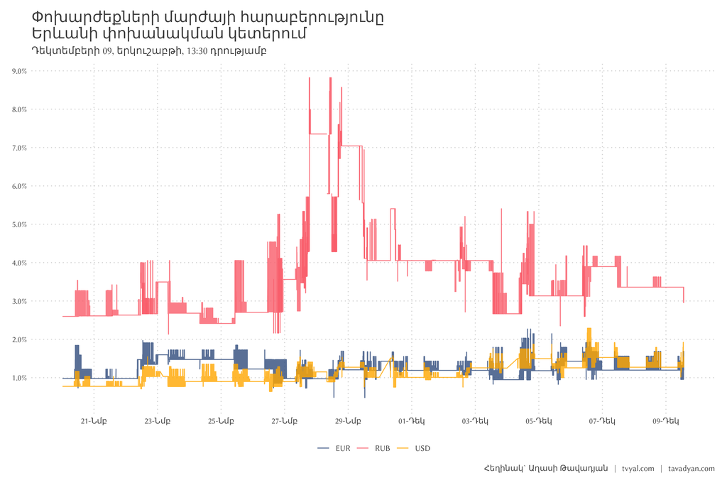

Որպեսզի հասկանանք, թե ինչ կարող է սպասվել հայկական դրամի փոխարժեքին, դիտարկենք ԱՄՆ դոլարի արժեքի պատմությունը ՀՀ դրամի նկատմամբ՝ սկսած 2012 թվականից: Գծապատկերում երևում են կայունության 3 շրջան, 3 ցնցում, Ռուսաստանի Դաշնության փոխարժեքի 2 ճգնաժամ և Արցախի կորստի ազդեցությունը:

Գծապատկեր 5

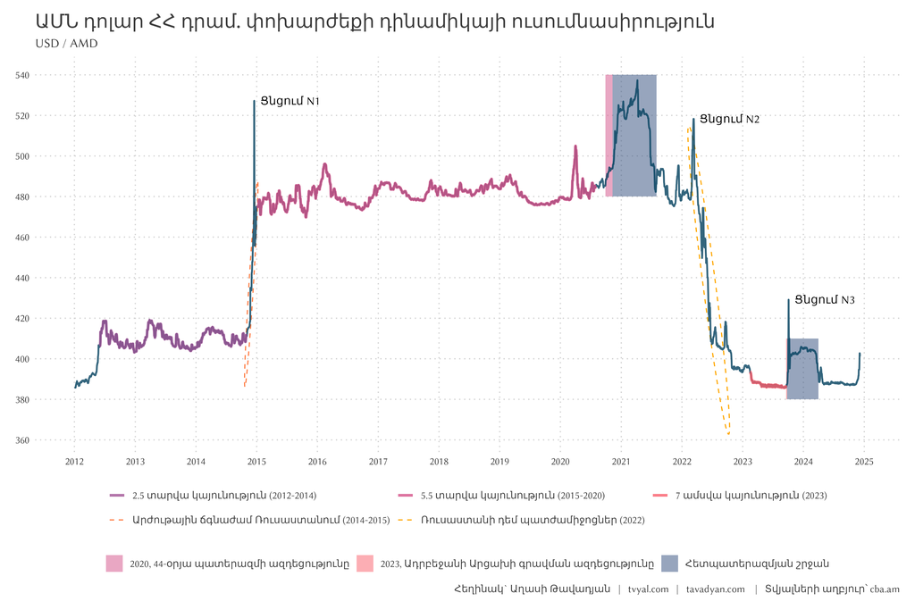

2012-2014 թվականներին ԱՄՆ դոլարի փոխարժեքը կայուն էր՝ մոտ 410 դրամի սահմաններում: 2014թ. երկրորդ կիսամյակում Ռուսաստանում սկսված ֆինանսական ճգնաժամը, որը պայմանավորված էր նավթի գների անկմամբ և Ղրիմի հետ կապված պատժամիջոցներով, հանգեցրեց տարածաշրջանի արժույթների, այդ թվում՝ եվրոյի և դրամի արժեզրկման: Հատկանշական է, որ եվրոյի արժեզրկումը աստիճանական էր, մինչդեռ դրամի արժեզրկումը եղավ կտրուկ և ապակայունացնող:

Թղթադրամի արժեքը հիմնված է հասարակության կոլեկտիվ վստահության վրա: 2020 թվականի 44-օրյա պատերազմից, ինչպես նաև 2023 թվականին Արցախի կորստից հետո, հասարակության մի մասը կորցրեց վստահությունը դեպի տնտեսությունը և դրամը: Քանի որ Հայաստանում միայն դրամն է պաշտոնական վճարամիջոց, բնակչությունը չի կարող երկար ժամանակ պահել արտարժույթ, ինչը հանգեցնում է դրամի պարբերական վերաարժևորման:

2022 թվականին ռուս-ուկրաինական հակամարտության սկզբում տեղի ունեցավ «Ցնցում N2»-ը: Չնայած շուկան սպասում էր դրամի արժեզրկման, Ռուսաստանից զգալի քանակությամբ արտարժույթի ներհոսքը հանգեցրեց հակառակ արդյունքի՝ դրամի արժևորման: Բանկային համակարգ կատարված փոխանցումները 2.5 անգամ աճեցին, իսկ Ռուսաստանից ներհոսքը՝ 4.5 անգամ: Այս ժամանակաշրջանին հաջորդեց կայունության երրորդ շրջանը, որը տևեց համեմատաբար կարճ՝ մինչև Արցախի գրավումը:

> Ձեզ կարող է հետաքրքրել նաև հետևյալ վերլուծությունը.

> [💸🔚🏦 Կապիտալի ներհոսքից մինչև արտահոսք. Հայաստանի տնտեսական հրաշքի ներքին խոհանոցը](https://www.tvyal.com/newsletter/2024/2024_09_16)։

Գծապատկեր 6

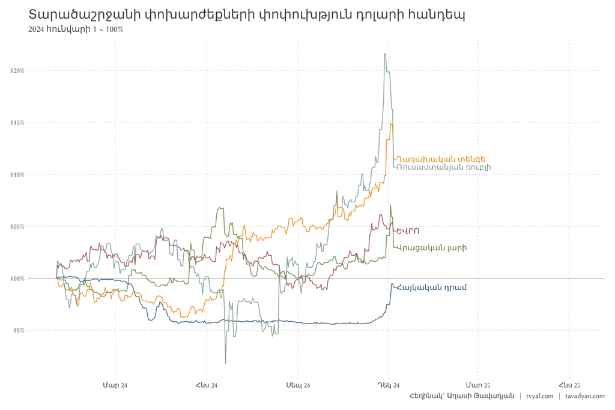

Հայաստանը զգալի կախվածություն ունի արտաքին ֆինանսական շուկաներից՝ հատկապես ռուսական ռուբլու շուկայից։ Այս պայմաններում փորձը ցույց է տալիս, որ ռուսական ռուբլու կտրուկ արժեզրկումը կարող է բացասաբար անդրադառնալ մեր տնտեսության վրա։ Այս պայմաններում չի բացառվում հայկական դրամի հետագա կտրուկ ցնցման հավանականությունը, որը կարող է խուճապ հարուցել հայկական շուկայում։ Այս սցենարի իրականացման պայմաններում 2025 թվականի ՀՆԱ-ի աճի հավանականությունը բավականին ցածր կլինի։ Այս սցենարը նաև կբերի պետական պարտքի կտրուկ աճի և վերջինիս՝ օրենքով սահմանված թույլատրելի սահմանից գերազանցման։ Կենտրոնական բանկը պետք է շատ զգոն լինի այս պայմաններում և թույլ չտա ավելորդ լարում փոխարժեքի շուկայում, որը կարող է հանգեցնել հայկական դրամի հանկարծակի թռիչքի։

Թեև իրական տնտեսության համար դրամի արժեզրկումը ձեռնտու է և կարող է թուլացնել դրամի հանկարծակի ցնցման հետագա հավանականությունը, սակայն այս քայլը ձեռնտու չէ կենտրոնական բանկին և կառավարությանը, քանի որ ԿԲ տեսանկյունից այն գնաճային է և կարող է հանգեցնել կապիտալի արտահոսքի, իսկ կառավարության տեսանկյունից՝ կմեծացնի պետական պարտքը և դրա սպասարկումը, ինչպես նաև կփոքրացնի ՀՆԱ ցուցանիշները դոլարային արտահայտությամբ։

> Ձեզ կարող է հետաքրքրել նաև հետևյալ վերլուծությունը.

> [💎🎭🔮️ Ոսկե Պատրանք. Հայաստանի արտահանման իրական պատկերը](https://www.tvyal.com/newsletter/2024/2024_09_02)։

Եթե հնարավոր է, խնդրում եմ այս նյութը ուղարկել նաև այն մարդկանց, ում այն կարծում եք կարող է հետաքրքրել:

**ԱՅՍ ՀՈԴՎԱԾԻ ՀՂՈՒՄԸ**

*Թավադյան, Աղ․Ա․ (2024) Դրամի դրաման և ռուբլու ռումբը [Drama of the Dram and Rumble of the Ruble], tvyal.com հարթակ [tvyal.com platform], 09-12-2024․ https://www.tvyal.com/newsletter/2024/2024_12_09*

**Արգելվում է այս հարթակի նյութերը արտատպել առանց հղում կատարելու։**

* Այս և մեր բոլոր այլ վերլուծությունների տվյալները վերցված են պաշտոնական աղբյուրներից։ Հաշվարկները ամբողջությամբ հասանելի են github-ում, դրանք կարելի է ստուգել` այցելելով [github-ի](https://github.com/tavad/tvyal_newsletter/blob/main/2024/) մեր էջը, որտեղ տրված են տվյալները, հաշվարկների և գծապատկերների կոդը։

# ՀԱՄԱԳՈՐԾԱԿՑՈՒԹՅՈՒՆ

## Եթե ուզում եք AI գործիքներով ձեր տվյալներից օգուտ քաղել` ԴԻՄԵՔ ՄԵԶ

### Մենք առաջարկում ենք

- Extensive databases for finding both international and local leads
- Exclusive reports on the Future of the Armenian Economy
- Work and browser automation to streamline operations and reduce staffing needs
- AI models for forecasting growth and optimizing various aspects of your business
- Advanced dashboarding and BI solutions
- Algorithmic trading

### Let’s Put Your Data to Work!

### ՄԻԱՑԵՔ ՄԵՐ ԹԻՄԻՆ

## ԶԼՄ հաղորդագրություն

### **[Դիտեք 1in.am-ին տված հարցազրույցը որը քաննարկում է դրամի արժեզրկումը](https://youtu.be/laJ7WozOlBw&t=34s)**

📺 Ռուբլու անկումը կարող է բացասաբար ազդել Հայաստանի վրա. կտուժեն արտահանողները և տուրիզմի ոլորտը 📺

[figure not shown]

### **[Դիտեք Հետքի հարցազրույցը տնտեսական խնդիրների և զարգացման խոչընդոտների մասին](https://youtu.be/ADGYZZlvF14)**

📺 Հայաստանից միլիարդավոր դոլարների ոսկու վերաարտահանումը կարճաժամկետ «փուչիկ» էր 📺

[figure not shown]

## English Summary

Հարգանքներով,  
Աղասի Թավադյան  
09.12.2024  
[tvyal.com](https://www.tvyal.com/)  
[tavadyan.com](https://www.tavadyan.com/)

[Was this email forwarded to you? Subscribe here.](https://www.tvyal.com/subscribe)

[Բաժանորդագրվեք](https://www.tvyal.com/subscribe)

**Ուշադրություն. Ձեր էլ.փոստը մեյլիսթի մեջ է, որի միջոցով ես կիսվում եմ շաբաթական նյութեր, որոնք հիմնականում ներկայացնում են Հայաստանի տնտեսությանը: Նյութերը ներառում են գծապատկերներ, [տվյալների բազաներ](https://github.com/tavad/tvyal_newsletter), տեսանյութեր, հոդվածներ, [առցանց վահանակներ](https://www.tvyal.com/projects), տնտեսական գործիքներ, կանխատեսումներ և հաշվետվություններ: Եթե ցանկանում եք չեղարկել բաժանորդագրությունը, խնդրում եմ տեղեկացրեք ինձ, և ես կհեռացնեմ ձեր էլ. փոստը ցուցակից: Գրեք նաև եթե ունեք մենկնաբանություններ:**

**Important! Your email is part of the mailing list where I share weekly materials primarily focused on the Armenian economy. These materials encompass charts, [databases](https://github.com/tavad/tvyal_newsletter), videos, articles, [online dashboards](https://www.tvyal.com/projects), economic tools, forecasts, and reports. If you wish to unsubscribe, please let me know, and I will remove your email from the list. Please share your comments as well․**